# Lab 04 - Parte 2

Caio Oliveira

July 3, 2017

# Tema: Você e suas perguntas

## Dados: Opiniões sobre filmes (small)

….

# Escolha das perguntas e motivação

Pessoalmente sou um grande fã de filmes de terror, filmes que deixam o coração acelerado e principalmente os momentos de tensão que ocorrem antes de uma grande cena, seja um susto ou a aparição do vilão principal.

Entretanto, mesmo gostando muito, sei que esses filmes sofrem preconceito em relãção ao seus roteiros e principalmente a produção pois, hoje em dia as pessoas que assistem e gostam de filmes estão muito mais críticas a qualidade dos mesmos.

Surgiu então a principal dúvida em relação a esses filmes: **Quão ruim são esses filmes?**. Essa pergunta obviamente se refere a parte das notas dadas pelos usuários, e como no laboratório anterior falamos também sobre filmes iremos utilizar os mesmos dados anteriores, e principalmente focar na variável de notas **rating**.

[figure not shown]

## Tratamento dos dados

Os dados foram tratados da mesma forma que para o trabalho anterior, só que a manipulação dos dataframes foi diferente para cada uma das perguntas.

```r
links <- read.csv("dados/links.csv")
movies <- read_csv("dados/movies.csv", col_types = cols(genres = col_character()))
ratings <- read.csv("dados/ratings.csv")
tags <- read.csv("dados/tags.csv")


merged.all.movies <- merge(ratings,movies,by = "movieId")
```

# Filmes que tem os gêneros Horror, Thriller tem geralmente pontuação mais baixa que os outros?

Essa pergunta é a base principal de tudo, o questionamento é contante, se existe realmente essa diferença grande de pontuação entre filmes que são desses gêneros e o resto.

Faremos isso em duas partes, a primeira usando a biblioteca **Rmisc** e depois utilizaremos **boot**(bootstrap) para calcularmos o mesmo intervalo de confiança e fazermos uma comparação.

## Sem bootstrap

Primeiramente usando **Rmisc** calcularemos o CI para os dois cojuntos de filmes que se encaixam no gênero Horror/Thriller (independentemente da quantidade de gêneros) e o resto dos outros gêneros de filmes, que obrigatoriamente não contêm esses gêneros.

Podemos ver que a média dos filmes que não contêm Horror ou Thriller nos seus gêneros é consideravelmente maior que dos que contêm, além de ter um intervalo de confiança menor pela quantidade de amostras ser maior

```r
horror <- merged.all.movies[grep("Horror", merged.all.movies$genres), ]
thriller <- merged.all.movies[grep("Thriller", merged.all.movies$genres), ]
all.the.rest <- merged.all.movies[!(merged.all.movies$movieId %in% horror$movieId),]
all.the.rest <- all.the.rest[!(all.the.rest$movieId %in% thriller$movieId),]
merged.horror.thriller <- rbind(horror,thriller)
merged.horror.thriller <- merged.horror.thriller[!duplicated(merged.horror.thriller),]
merged.horror.thriller$category <- "Thriller/Horror"
all.the.rest$category <- "Resto das categorias"

teste <- rbind(all.the.rest,merged.horror.thriller)
teste$category <- as.factor(teste$category)
teste.summarized <- Rmisc::summarySE(teste, measurevar="rating",groupvars = c("category"))
print(teste.summarized, row.names = FALSE)
```

```
##              category     N   rating       sd          se          ci
##  Resto das categorias 71462 3.559752 1.060794 0.003968198 0.007777657
##       Thriller/Horror 28542 3.503188 1.050129 0.006215851 0.012183362
```

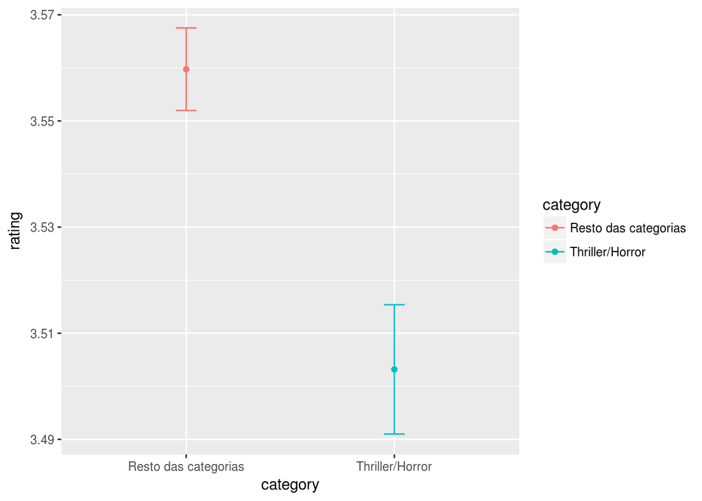

```r
pd <- position_dodge(0.1)

ggplot(teste.summarized, aes(x=category, y=rating, colour=category, group = category)) +
    geom_errorbar(aes(ymin=rating-ci, ymax=rating+ci), width=.1, position=pd) +
    geom_point(position=pd)
```

## Com bootstrap

Tentaremos tirar a prova completa agora com a biblioteca **boot** que replica a amostra de forma a tentar calcular um CI mais preciso.

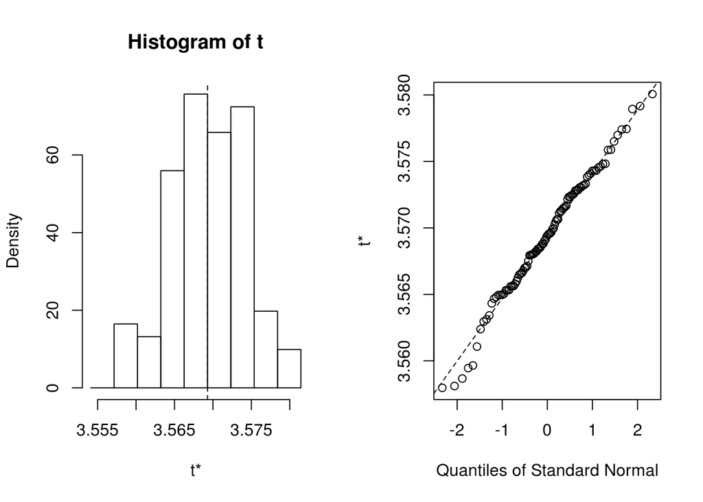

```r
results <- boot(data=all.the.rest, statistic=bs,
                R=100, formula=rating~movieId)

plot(results, index=1)
```

```r
boot.ci(results, type="norm")
```

```
## BOOTSTRAP CONFIDENCE INTERVAL CALCULATIONS
## Based on 100 bootstrap replicates
##
## CALL :
## boot.ci(boot.out = results, type = "norm")
##
## Intervals :
## Level      Normal
## 95%   ( 3.560,  3.578 )
## Calculations and Intervals on Original Scale
```

```r
boot.ci(results, type = "basic")
```

```
## BOOTSTRAP CONFIDENCE INTERVAL CALCULATIONS
## Based on 100 bootstrap replicates
##
## CALL :
## boot.ci(boot.out = results, type = "basic")
##
## Intervals :
## Level      Basic
## 95%   ( 3.56,  3.58 )
## Calculations and Intervals on Original Scale
## Some basic intervals may be unstable
```

```r
boot.ci(results, type = "perc")
```

```
## BOOTSTRAP CONFIDENCE INTERVAL CALCULATIONS
## Based on 100 bootstrap replicates
##
## CALL :
## boot.ci(boot.out = results, type = "perc")
##
## Intervals :
## Level     Percentile
## 95%   ( 3.558,  3.579 )
## Calculations and Intervals on Original Scale
## Some percentile intervals may be unstable
```

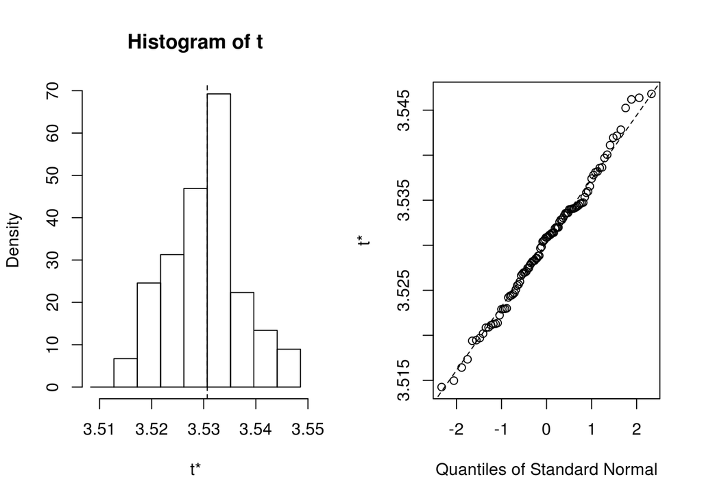

```r
results <- boot(data=merged.horror.thriller, statistic=bs,
                R=100, formula=rating~movieId)

plot(results, index=1)
```

```r
boot.ci(results, type="norm")
```

```
## BOOTSTRAP CONFIDENCE INTERVAL CALCULATIONS
## Based on 100 bootstrap replicates
##
## CALL :
## boot.ci(boot.out = results, type = "norm")
##
## Intervals :
## Level      Normal
## 95%   ( 3.517,  3.545 )
## Calculations and Intervals on Original Scale
```

```r
boot.ci(results, type = "basic")
```

```
## BOOTSTRAP CONFIDENCE INTERVAL CALCULATIONS
## Based on 100 bootstrap replicates
##
## CALL :
## boot.ci(boot.out = results, type = "basic")
##
## Intervals :
## Level      Basic
## 95%   ( 3.515,  3.546 )
## Calculations and Intervals on Original Scale
## Some basic intervals may be unstable
```

```r
boot.ci(results, type = "perc")
```

```
## BOOTSTRAP CONFIDENCE INTERVAL CALCULATIONS
## Based on 100 bootstrap replicates
##
## CALL :
## boot.ci(boot.out = results, type = "perc")
##
## Intervals :
## Level     Percentile
## 95%   ( 3.516,  3.546 )
## Calculations and Intervals on Original Scale
## Some percentile intervals may be unstable
```

# Entre os dois qual tem a maior nota? Horror ou Thriller?

Muitas pessoas confundem filmes de Horror com Thriller. Entretanto são coisas diferentes e bem definidas, que suas definições podem ajudar a entendermos os resultados dessa pergunta.

**Horror:** forte impressão de repulsa ou desagrado, acompanhada ou não de arrepio, gerada pela percepção, intuição, lembrança de algo horrendo, ameaçador, repugnante; pavor.

**Thriller:** Também pode ser classificado como suspense, é um gênero da literatura, filmes, jogos eletrônicos e televisão que usa o suspense, tensão e excitação como principais elementos do gênero. O seu principal subgênero é o “thriller psicológico”.

Podemos ver que o que muitas pessoas chamam de Terror ou mesmo Horror é na verdade um filme do gênero Thriller e vice-versa. Nesse sentido a ideia dessa pergunta é olhar para dentro desse universo e analisar qual dessas duas categorias tem melhores notas.

## Sem bootstrap

Novamente vamos fazer o calculo do CI utilizando a biblioteca **Rmisc** para cada uma das categorias separadamente.

Observamos a média bem superior para filmes da categoria **Thriller**, além de um CI menor, que é consequência , novamente, de uma amostragem maior.

```r
horror.only <- horror[!(horror$movieId %in% thriller$movieId),]
horror.only$category <- "Horror"
thriller.only <- thriller[!(thriller$movieId %in% horror$movieId),]
thriller.only$category <- "Thriller"

merged.only <- rbind(horror.only,thriller.only)
merged.only.summarized <- Rmisc::summarySE(merged.only, measurevar = "rating", groupvars = c("category"))
print(merged.only.summarized,row.names=FALSE)
```

```
##  category     N   rating       sd          se         ci
##    Horror  3302 3.386130 1.104668 0.019223984 0.03769214
##  Thriller 21752 3.561856 1.023235 0.006937866 0.01359872
```

Aqui de forma gráfica podemos ver essa diferença acentuada principalmente entre os limites superior e inferior entre as categorias. Como principalmente a diferença entre as médias.

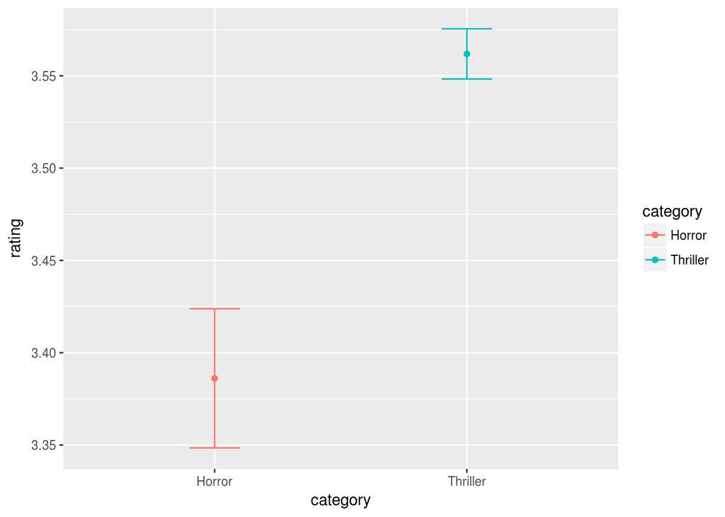

```r
ggplot(merged.only.summarized, aes(x=category, y=rating, fill=category, colour=category)) +
    geom_errorbar(aes(ymin=rating-ci, ymax=rating+ci),
                  width=.2,                    # Width of the error bars
                  position=position_dodge(.9)) +  geom_point(position=pd)
```

## Com bootstrap

Calculando cada categoria separadamente com o **bootstrap** poderemos ver em melhor precisão se essa diferença é realmente tão acentuada assim, principalemente para o caso da média que era 0.2 de diferença entre as duas categorias.

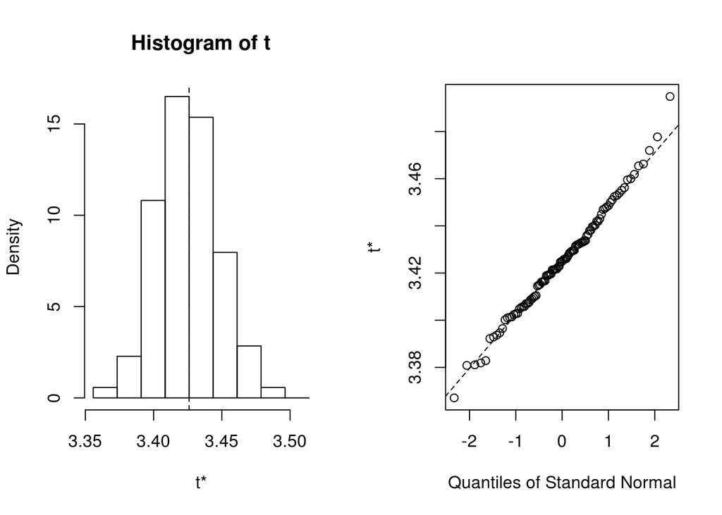

```r
results <- boot(data=horror.only, statistic=bs,
                R=100, formula=rating~movieId)


plot(results, index=1)
```

```r
boot.ci(results, type = "norm")
```

```
## BOOTSTRAP CONFIDENCE INTERVAL CALCULATIONS
## Based on 100 bootstrap replicates
##
## CALL :
## boot.ci(boot.out = results, type = "norm")
##
## Intervals :
## Level      Normal
## 95%   ( 3.382,  3.472 )
## Calculations and Intervals on Original Scale
```

```r
boot.ci(results, type = "basic")
```

```
## BOOTSTRAP CONFIDENCE INTERVAL CALCULATIONS
## Based on 100 bootstrap replicates
##
## CALL :
## boot.ci(boot.out = results, type = "basic")
##
## Intervals :
## Level      Basic
## 95%   ( 3.378,  3.471 )
## Calculations and Intervals on Original Scale
## Some basic intervals may be unstable
```

```r
boot.ci(results, type = "perc")
```

```
## BOOTSTRAP CONFIDENCE INTERVAL CALCULATIONS
## Based on 100 bootstrap replicates
##
## CALL :
## boot.ci(boot.out = results, type = "perc")
##
## Intervals :
## Level     Percentile
## 95%   ( 3.381,  3.474 )
## Calculations and Intervals on Original Scale
## Some percentile intervals may be unstable
```

O mesmo aconteceu para os filmes da categoria **Thriller**, e assim podemos concluir com o mesmo grau de certeza da questão anterior que os filmes que se encontram na categoria **Horror** recebem notas menores do que em Thriller. Isso é explicado porque geralmente filmes de horror tem bem mais cenas sangrentas que pessoas de estômago fraco não se dão muito bem e sendo assim dão notas menores por traumatizar ou ter cenas difíceis de esquecer.

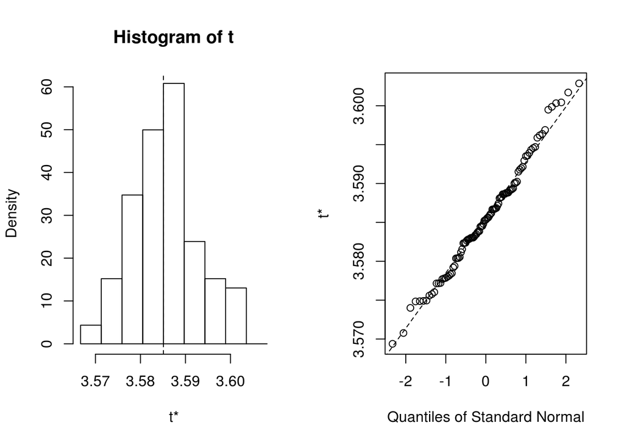

```r
results <- boot(data=thriller.only, statistic=bs,
                R=100, formula=rating~movieId)


plot(results, index=1)
```

```r
boot.ci(results, type = "norm")
```

```
## BOOTSTRAP CONFIDENCE INTERVAL CALCULATIONS
## Based on 100 bootstrap replicates
##
## CALL :
## boot.ci(boot.out = results, type = "norm")
##
## Intervals :
## Level      Normal
## 95%   ( 3.571,  3.599 )
## Calculations and Intervals on Original Scale
```

```r
boot.ci(results, type = "basic")
```

```
## BOOTSTRAP CONFIDENCE INTERVAL CALCULATIONS
## Based on 100 bootstrap replicates
##
## CALL :
## boot.ci(boot.out = results, type = "basic")
##
## Intervals :
## Level      Basic
## 95%   ( 3.569,  3.598 )
## Calculations and Intervals on Original Scale
## Some basic intervals may be unstable
```

```r
boot.ci(results, type = "perc")
```

```
## BOOTSTRAP CONFIDENCE INTERVAL CALCULATIONS
## Based on 100 bootstrap replicates
##
## CALL :
## boot.ci(boot.out = results, type = "perc")
##
## Intervals :
## Level     Percentile
## 95%   ( 3.573,  3.601 )
## Calculations and Intervals on Original Scale
## Some percentile intervals may be unstable
```

# Dentre eles (Horror e Thriller) os que tem comédia possuem notas maiores?

Outra curiosidade é se o gênero **Comedia** influencia as notas dos filmes Horror/Thriller. Como experiencia todos os filmes que eu mesmo assisti ou vi críticas, que envolvessem comédia eram piores do que os filmes puramente de Horror ou Thriller.

Usaremos o mesmo sistema anterior para responder essas questões.

## Sem bootstrap

Fazendo os cálculos com **Rmisc** podemos ver logo a primeira impressão que apesar dos filmes com comédia terem a média menor, a diferença é pequena. A diferença da amostra é realmente notável, e a diferença de CI é quase 3 vezes maior para os filmes que possuem Comédia nos gêneros.

```r
comedy.ones <- merged.horror.thriller[grep("Comedy", merged.horror.thriller$genres), ]
comedy.ones$category <- "Comedy"
comedy.less <- merged.horror.thriller[!(merged.horror.thriller$movieId %in% comedy.ones$movieId),]
comedy.less$category <- "No comedy"
merged.comedy <- rbind(comedy.less,comedy.ones)
merged.comedy$category <- as.factor(merged.comedy$category)

merged.comedy.summarized <- Rmisc::summarySE(merged.comedy,measurevar = "rating", groupvars = c("category"))
print(merged.comedy.summarized, rown.names = FALSE)
```

```
##    category     N  rating       sd          se         ci
## 1    Comedy  3618 3.45702 1.101632 0.018314805 0.03590837
## 2 No comedy 24924 3.50989 1.042295 0.006602094 0.01294050
```

Aqui de forma gráfica podemos ver o quão próximo são os limites superior(Comedy) e o inferior(No comedy) das duas categorias. Mas que mesmo assim a média delas está afastada.

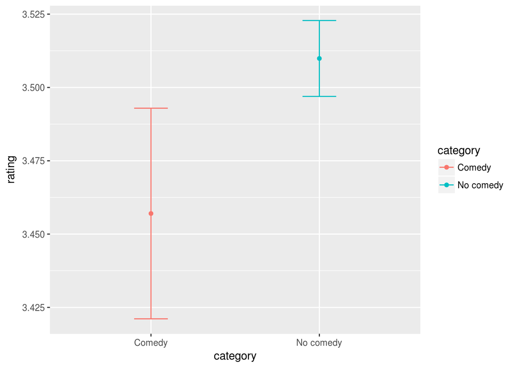

```r
ggplot(merged.comedy.summarized, aes(x=category, y=rating, color = category)) +
    geom_errorbar(aes(ymin=rating-ci, ymax=rating+ci),
                  width=.2,                    # Width of the error bars
                  position=position_dodge(.9)) + geom_point(position = pd)
```

## Com bootstrap

Usando o **bootstrap** vemos que para os filmes que tem comédia dentre seus gêneros a média subiu 0.02 pontos, mas o CI continuou o mesmo.

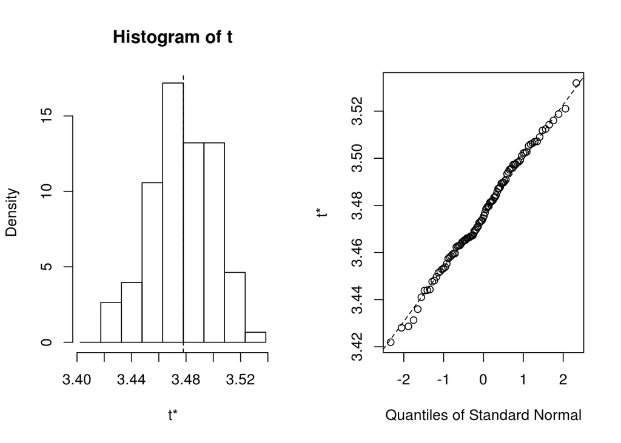

```r
results <- boot(data=comedy.ones, statistic=bs,
                R=100, formula=rating~movieId)


plot(results, index=1)
```

```r
boot.ci(results, type = "norm")
```

```
## BOOTSTRAP CONFIDENCE INTERVAL CALCULATIONS
## Based on 100 bootstrap replicates
##
## CALL :
## boot.ci(boot.out = results, type = "norm")
##
## Intervals :
## Level      Normal
## 95%   ( 3.434,  3.524 )
## Calculations and Intervals on Original Scale
```

```r
boot.ci(results, type = "basic")
```

```
## BOOTSTRAP CONFIDENCE INTERVAL CALCULATIONS
## Based on 100 bootstrap replicates
##
## CALL :
## boot.ci(boot.out = results, type = "basic")
##
## Intervals :
## Level      Basic
## 95%   ( 3.436,  3.528 )
## Calculations and Intervals on Original Scale
## Some basic intervals may be unstable
```

```r
boot.ci(results, type = "perc")
```

```
## BOOTSTRAP CONFIDENCE INTERVAL CALCULATIONS
## Based on 100 bootstrap replicates
##
## CALL :
## boot.ci(boot.out = results, type = "perc")
##
## Intervals :
## Level     Percentile
## 95%   ( 3.428,  3.520 )
## Calculations and Intervals on Original Scale
## Some percentile intervals may be unstable
```

Já para os filmes que não contem o gênero comédia a média aumentou em 0.03 pontos, e o intervalo de confiança aumentou somente 0.002. Assim não contendo uma alteração significativa podemos concluir que os filmes que contêm comédia recebem notas mais baixas do que os que não contêm.

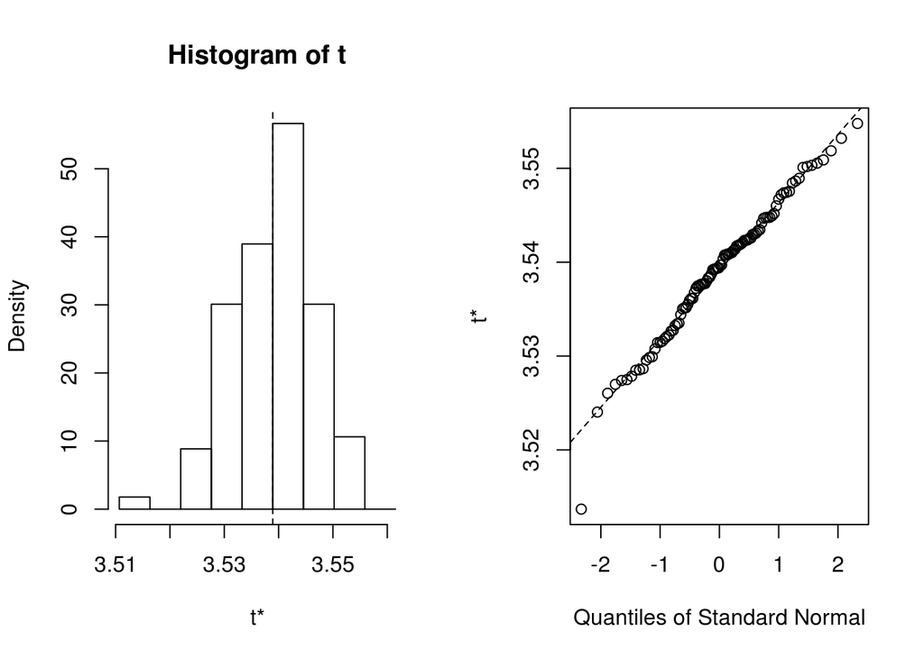

```r
results <- boot(data=comedy.less, statistic=bs,
                R=100, formula=rating~movieId)


plot(results, index=1)
```

```r
boot.ci(results, type = "norm")
```

```
## BOOTSTRAP CONFIDENCE INTERVAL CALCULATIONS
## Based on 100 bootstrap replicates
##
## CALL :
## boot.ci(boot.out = results, type = "norm")
##
## Intervals :
## Level      Normal
## 95%   ( 3.525,  3.553 )
## Calculations and Intervals on Original Scale
```

```r
boot.ci(results, type = "basic")
```

```
## BOOTSTRAP CONFIDENCE INTERVAL CALCULATIONS
## Based on 100 bootstrap replicates
##
## CALL :
## boot.ci(boot.out = results, type = "basic")
##
## Intervals :
## Level      Basic
## 95%   ( 3.525,  3.553 )
## Calculations and Intervals on Original Scale
## Some basic intervals may be unstable
```

```r
boot.ci(results, type = "perc")
```

```
## BOOTSTRAP CONFIDENCE INTERVAL CALCULATIONS
## Based on 100 bootstrap replicates
##
## CALL :
## boot.ci(boot.out = results, type = "perc")
##
## Intervals :
## Level     Percentile
## 95%   ( 3.525,  3.552 )
## Calculations and Intervals on Original Scale
## Some percentile intervals may be unstable
```